# Spatio-temporal Under-five Mortality Methods for Estimation

## Load Package and Data

`DemoData` contains model survey data provided by DHS. Note that this data is fake, and does not represent any real country’s data. Data similar to the `DemoData` data used in this vignette can be obtained by using `getBirths`. `DemoMap` contains geographic data from the 1995 Uganda Admin 1 regions defined by DHS. Data similar to the `DemoMap` data used in this vignette can be obtained by using `read_shape`.

First, we load the package and load the necessary data. INLA is not in a standard repository, so we check if it is available and install it if it is not.

```r
library(SUMMER)
if (!isTRUE(requireNamespace("INLA", quietly = TRUE))) {
  install.packages('INLA', repos = 'https://www.math.ntnu.no/inla/R/stable')
}

data(DemoData)
data(DemoMap)
```

```r
summary(DemoData)
```

```
##      Length Class      Mode
## 1999 8      data.frame list
## 2003 8      data.frame list
## 2007 8      data.frame list
## 2011 8      data.frame list
## 2015 8      data.frame list
```

```r
head(DemoData[[1]])
```

```
##   clustid id  region  time  age  weights        strata died
## 1       1  1 eastern 00-04    0 1.057703 eastern.rural    0
## 2       1  1 eastern 00-04 1-11 1.057703 eastern.rural    0
## 3       1  1 eastern 00-04 1-11 1.057703 eastern.rural    0
## 4       1  1 eastern 00-04 1-11 1.057703 eastern.rural    0
## 5       1  1 eastern 00-04 1-11 1.057703 eastern.rural    0
## 6       1  1 eastern 00-04 1-11 1.057703 eastern.rural    0
```

`DemoData` is obtained by processing the raw DHS birth data (in .dta format) in R. The raw file of birth recodes can be downloaded from the DHS website https://dhsprogram.com/data/Download-Model-Datasets.cfm. For this example dataset, no registration is needed. For real DHS survey datasets, permission to access needs to be registered with DHS directly. `DemoData` contains a small sample of the observations in this dataset randomly assigned to $5$ example DHS surveys.

Here we demonstrate how to split the raw data into person-month format from. Notice that to read the file from early version of stata, the package `readstata13` is required. The following script is based on the example dataset `ZZBR62FL.DTA` available from the DHS website. We use the interaction of v024 and v025 as the strata indicator for the purpose of demonstration.

```r
library(readstata13)
my_fp <- "data/ZZBR62DT/ZZBR62FL.DTA"
dat <- getBirths(filepath = my_fp, surveyyear = 2015, strata = c("v024", "v025"))
dat <- dat[,c("v001","v002","v024","per5","ageGrpD","v005","strata","died")]
colnames(dat) <- c("clustid","id","region","time","age","weights","strata","died")
```

## Make Country Summary

Next, we obtain Horvitz-Thompson estimators using `countrySummary_mult`.

```r
years <- levels(DemoData[[1]]$time)

data <- countrySummary_mult(births = DemoData, years = years, idVar = "id", regionVar = "region",
                           timeVar = "time", clusterVar = "~clustid+id", ageVar = "age",
                           weightsVar = "weights", geo.recode = NULL)
```

## Read Maps

In this step, we separate the output from `read_shape` to use as function arguments.

```r
    geo <- DemoMap$geo
    mat <- DemoMap$Amat
```

## Make Priors

Using our adjacency matrix, we simulate hyperpriors using `simhyper`. The default INLA analysis scales the marginal variance of all structured random effects, so we only need to one set of hyperparameters with `only.iid` set to true.

```r
priors <- simhyper(R = 2, nsamp = 1e+05, nsamp.check = 5000, Amat = mat, only.iid = TRUE)
```

## Prepare data for meta analysis

Before fitting the model, we first aggregate estimators from different surveys.

```r
dim(data)
```

```
## [1] 150  10
```

```r
data <- aggregateSurvey(data)
dim(data)
```

```
## [1] 30 10
```

## Fit INLA Model for national estimates

First, we ignore the subnational estimates, and fit a model with temporal random effects only. In this part, we use the subset of data region variable being “All”.

### Period model

In fitting this model, we first define the list of time periods we wish to project the estimates on. First we can fit a Random Walk 2 only model defined on the 5-year period.

```r
years.all <- c(years, "15-19")
fit1 <- fitINLA(data = data, geo = NULL, Amat = NULL, year_names = years.all, year_range = c(1985, 2019), priors = priors, rw = 2, is.yearly=FALSE, m = 5)
```

### Yearly model

Similarly as before, we can estimate the Random Walk 2 random effects on the yearly scale.

```r
fit2 <- fitINLA(data = data, geo = NULL, Amat = NULL, year_names = years.all, year_range = c(1985, 2019), priors = priors, rw = 2, is.yearly=TRUE, m = 5)
```

### Obtain smoothed estimates

The marginal posteriors are already stored in the fitted object. We use the following function to extract and re-arrange them.

```r
out1 <- projINLA(fit1, is.yearly = FALSE)
out2 <- projINLA(fit2, is.yearly = TRUE)
```

We can compare the results visually using the function below.

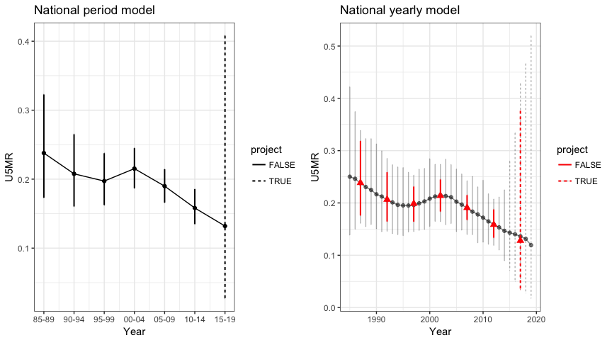

```r
library(ggplot2)
library(gridExtra)
g <- NULL
g[[1]] <- plot(out1, is.yearly=FALSE, is.subnational=FALSE) + ggtitle("National period model")
g[[2]] <- plot(out2, is.yearly=TRUE, is.subnational=FALSE) + ggtitle("National yearly model")
grid.arrange(grobs=g, ncol = 2)
```

## Fit INLA model for subnational estimates

Similarly we can fit the full model on all subnational regions.

### Period model

```r
fit3 <- fitINLA(data = data, geo = geo, Amat = mat, year_names = years.all, year_range = c(1985, 2019), priors = priors, rw = 2, is.yearly=FALSE, m = 5)
out3 <- projINLA(fit3, Amat = mat, is.yearly = FALSE)
```

### Yearly model with type IV interaction

```r
fit4 <- fitINLA(data = data, geo = geo, Amat = mat, year_names = years.all, year_range = c(1985, 2019), priors = priors, rw = 2, is.yearly=TRUE, m = 5, type.st = 4)
out4 <- projINLA(fit4, Amat = mat, is.yearly = TRUE)
```

### Compare plots

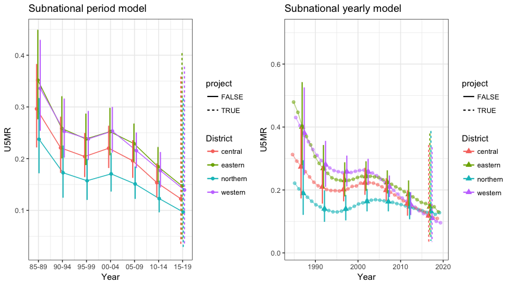

```r
g2 <- NULL
g2[[1]] <- plot(out3, is.yearly=FALSE, is.subnational=TRUE) + ggtitle("Subnational period model")
g2[[2]] <- plot(out4, is.yearly=TRUE, is.subnational=TRUE) + ggtitle("Subnational yearly model")
grid.arrange(grobs=g2, ncol = 2)
```

### Map visualization of changes across time

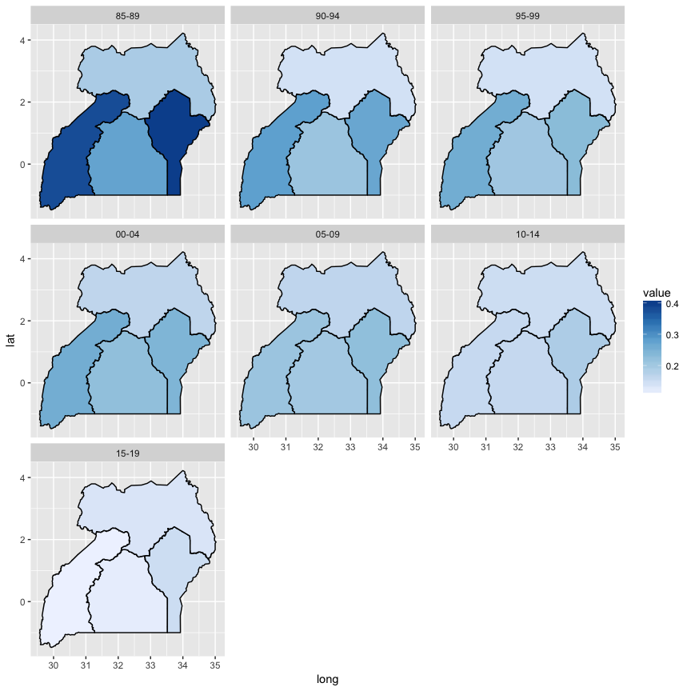

```r
mapPlot(data = subset(out4, is.yearly==F), geo = DemoMap$geo, variables=c("Year"), values = c("med"), by.data = "District", by.geo = "NAME_final", is.long=TRUE)
```

## Simple spatial smoothing examples

In this section we show two simple spatial smoothing example using data created from the model survey data, and a Kenya Admin 1 map with 8 regions.

```r
data(DemoData2)
data(DemoMap2)
```

The `DemoData2` dataset contains the survey information and two response variables, age and tobacco usage.

```r
head(DemoData2)
```

```
##   clustid id  region age  weights        strata tobacco.use
## 1       1  1 nairobi  30 1.057703 nairobi.urban           0
## 2       1  3 nairobi  22 1.057703 nairobi.urban           0
## 3       1  4 nairobi  42 1.057703 nairobi.urban           0
## 4       2  4  nyanza  25 1.057703  nyanza.urban           0
## 5       1  5 nairobi  25 1.057703 nairobi.urban           0
## 6       1  6 nairobi  37 1.057703 nairobi.urban           0
```

### Normal model

We first generate some synthetic normally distributed variable for height for each observation. Suppose we denote the height of observation $k$ in area $i$ to be $x_{ik}$, and the associated design weight to be $w_{ik}$. Under the design-based approach to inference, we can calculate the weighted estimator of mean height to be
$$\hat{\mu_i} = \frac{\sum_k w_{ik}x_{ik}}{\sum_k w_{ik}}$$
and the associated variance $\widehat{var}(\hat{\mu_i})$. We then use INLA to fit the following Bayesian hierarchical model:
$$\begin{eqnarray*}
\hat\mu_i &\sim & \mbox{Normal}( \mu_i, \widehat{var}(\hat{\mu_i}) )\\
\mu_i &=& \beta + \epsilon_i+\delta_i,\\
\epsilon_i &\sim & \mbox{Normal}(0,\sigma_\epsilon^2)\\
\delta_i &\sim & \mbox{ICAR}(\sigma_\delta^2)
\end{eqnarray*}$$

To simulate from this generative model, we first simulate from the ICAR random fields as follows

```r
set.seed(123)
sim.Q <- function(Q){
  eigenQ <- eigen(Q)
  rankQ <- qr(Q)$rank
  sim <- as.vector(eigenQ$vectors[,1:rankQ] %*%
           matrix(
             rnorm(rep(1, rankQ), rep(0, rankQ), 1/sqrt(eigenQ$values[1:rankQ])),
           ncol = 1))
  sim
}
Q <- DemoMap2$Amat * -1
diag(Q) <- 0
diag(Q) <- -1 * apply(Q, 2, sum)
struct.error <- sim.Q(Q)
```

We generate the mean height for each region by

```r
mu <- 70 + struct.error
regions <- colnames(DemoMap2$Amat)
```

We generate the data by

```r
DemoData2$height <- rnorm(dim(DemoData2)[1])*8 + mu[match(DemoData2$region, regions)]
```

We can use the `fitspace()` function to obtain both the survey-weighted direct estimates and the smoothed estimates from INLA.

```r
fit <- fitSpace(data=DemoData2, geo=DemoMap2$geo, Amat=DemoMap2$Amat, family="gaussian", responseVar="height", strataVar="strata", weightVar="weights", regionVar="region", clusterVar = "~clustid+id", hyper=NULL, CI = 0.95)
```

```
## FUN is not specified, default to be no transformation
```

The posterior median of the structured random effects can be obtained from:

```r
fit$fit$summary.random$reg.struct[, "0.5quant"]
```

```
## [1]  7.604647e-04  3.338796e-04  4.823497e-05  2.902533e-04 -7.429920e-04
## [6] -1.437789e-06 -4.312828e-04 -2.366215e-04
```

We can compare the posterior of the structured random effects with the truth values from the simulation.

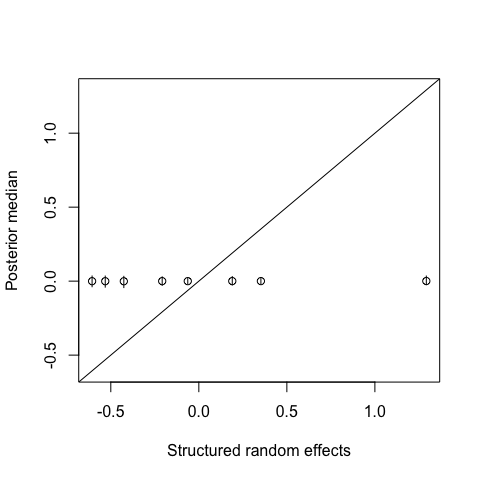

```r
lim <- range(c(struct.error, fit$fit$summary.random$reg.struct[, "0.025quant"],
               fit$fit$summary.random$reg.struct[, "0.975quant"]))
plot(struct.error, fit$fit$summary.random$reg.struct[, "0.5quant"],  xlab = "Structured random effects", ylab = "Posterior median", xlim = lim, ylim = lim)
segments(x0 = struct.error, x1 = struct.error,
         y0 = fit$fit$summary.random$reg.struct[, "0.025quant"],
         y1 = fit$fit$summary.random$reg.struct[, "0.975quant"])
abline(c(0, 1))
```

```r
fit$HT[, c("HT.est", "HT.sd", "region")]
```

```
##     HT.est     HT.sd       region
## 2 71.41449 0.2589442      nairobi
## 1 70.18577 0.1981691      central
## 4 70.26359 0.3135852        coast
## 3 70.61735 0.2736472      eastern
## 6 69.11042 0.3521545       nyanza
## 8 70.02198 0.2920432  rift valley
## 7 70.09129 0.2648998      western
## 5 69.59892 0.2658214 northeastern
```

The posterior summaries of $\mu_i|\hat\mu_i$ can be obtained by

```r
fit$smooth[, c("mean", "sd", "median", "lower", "upper", "region")]
```

```
##       mean        sd   median    lower    upper       region
## 1 71.00236 0.3905001 71.06410 70.15380 71.63569      nairobi
## 2 70.19188 0.1756492 70.19546 69.83663 70.53644      central
## 3 70.23861 0.2514524 70.23603 69.73345 70.75049        coast
## 4 70.46993 0.2495154 70.45717 70.03450 70.98151      eastern
## 5 69.59038 0.3939581 69.56975 68.84515 70.31200       nyanza
## 6 70.08966 0.2448704 70.10776 69.58095 70.54653  rift valley
## 7 70.12937 0.2246824 70.14224 69.66597 70.55879      western
## 8 69.80773 0.2808184 69.79760 69.26907 70.32188 northeastern
```

We can compare the direct and smoothed estimates and their standard errors.

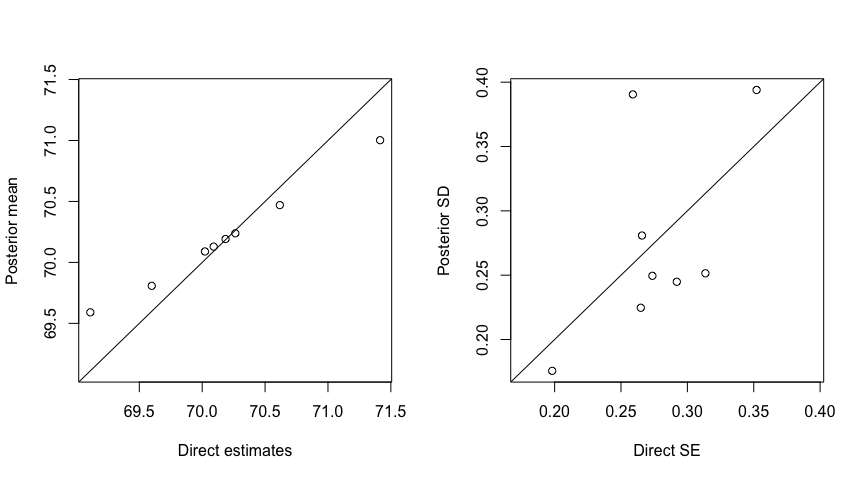

```r
par(mfrow = c(1, 2))
lim <- range(c(fit$HT$HT.est, fit$smooth$mean))
plot(fit$HT$HT.est, fit$smooth$mean, xlim = lim, ylim = lim, xlab = "Direct estimates", ylab = "Posterior mean")
abline(c(0, 1))
lim <- range(c(fit$HT$HT.sd, fit$smooth$sd))
plot(fit$HT$HT.sd, fit$smooth$sd, xlim = lim, ylim = lim, xlab = "Direct SE", ylab = "Posterior SD")
abline(c(0, 1))
```

We can also compare the direct and smoothed estimates on the map.

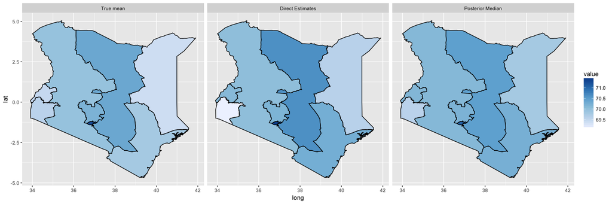

```r
combined <- merge(fit$HT, fit$smooth, by = "region")
combined$truth <- mu[match(combined$region, regions)]
mapPlot(data = combined, geo = DemoMap2$geo, variables=c("truth", "HT.est", "median"), labels = c("True mean", "Direct Estimates", "Posterior Median"), by.data = "region", by.geo = "NAME_final", is.long=FALSE)
```

### Binary model with logistic link

Similar as in the previous subsection, suppose we denote the tobacco usage of observation $k$ in area $i$ to be $y_{ik}$, and the associated design weight to be $w_{ik}$. Under the design-based approach to inference, we can calculate the weighted estimator of prevalence to be
$$\hat{p_i} = \frac{\sum_k w_{ik}y_{ik}}{\sum_k w_{ik}}$$
and the associated variance $\widehat{var}(\hat{p_i})$. By delta method, if we denote $\hat\theta_{i} = \log(\frac{\hat p_i}{1-\hat p_i})$, the asymptotic distribution of $\hat\theta_{i}$ is
$$\hat\theta_i \sim \mbox{Normal}(\log(\frac{p_i}{1-p_i}), \hat V_i), \;\;\;\; \hat V_i = \frac{\widehat{var}(\hat{p_i})}{(\hat p_i (1 - \hat p_i))^2}$$
We then use INLA to fit the following Bayesian hierarchical model:
$$\begin{eqnarray*}
\hat\theta_i &=& \log\left( \dfrac{\hat{p_i}}{1-\hat{p_i}} \right) \sim \mbox{Normal}( \theta_i,\hat{V}_i )\\
\theta_i &=& \beta + \epsilon_i+\delta_i,\\
\epsilon_i &\sim & \mbox{Normal}(0,\sigma_\epsilon^2)\\
\delta_i &\sim & \mbox{ICAR}(\sigma_\delta^2)
\end{eqnarray*}$$

We can use the `fitspace()` function to obtain both the survey-weighted direct estimates and the smoothed estimates from INLA.

```r
fit <- fitSpace(data=DemoData2, geo=DemoMap2$geo, Amat=DemoMap2$Amat, family="binomial", responseVar="tobacco.use", strataVar="strata", weightVar="weights", regionVar="region", clusterVar = "~clustid+id", hyper=NULL, CI = 0.95)
```

```
## FUN is not specified, default to be expit()
```

The direct estimates of the prevalence of tobacco usage, i.e., $\hat p_i$ accounting for survey design are

```r
fit$HT[, c("HT.est.original", "HT.variance.original", "region")]
```

```
##   HT.est.original HT.variance.original       region
## 2      0.02748435         3.263723e-05      nairobi
## 1      0.04269545         6.222132e-05      central
## 4      0.07381327         7.796782e-05        coast
## 3      0.03453175         1.293472e-04      eastern
## 6      0.02809128         4.460260e-05       nyanza
## 8      0.07163454         2.165121e-04  rift valley
## 7      0.03462895         9.602971e-05      western
## 5      0.03735942         3.724319e-05 northeastern
```

The logit transformed direct estimates, $\hat\theta_i$ and the associated asymptotic standard deviations are

```r
fit$HT[, c("HT.est", "HT.sd", "region")]
```

```
##      HT.est     HT.sd       region
## 2 -3.566270 0.2137345      nairobi
## 1 -3.110029 0.1929914      central
## 4 -2.529537 0.1291590        coast
## 3 -3.330734 0.3411316      eastern
## 6 -3.543803 0.2446150       nyanza
## 8 -2.561848 0.2212583  rift valley
## 7 -3.327823 0.2931361      western
## 5 -3.249095 0.1696911 northeastern
```

The posterior summaries of $\theta_i|\hat\theta_i$ can be obtained by

```r
fit$smooth[, c("mean", "sd", "median", "lower", "upper", "region")]
```

```
##        mean        sd    median     lower     upper       region
## 1 -3.413011 0.1975403 -3.408581 -3.811719 -3.039909      nairobi
## 2 -3.111458 0.1683809 -3.110953 -3.443773 -2.781261      central
## 3 -2.615333 0.1321753 -2.615062 -2.875354 -2.356882        coast
## 4 -3.184440 0.2414235 -3.174090 -3.688738 -2.731562      eastern
## 5 -3.397220 0.2183764 -3.391888 -3.839304 -2.985165       nyanza
## 6 -2.783291 0.2004619 -2.792069 -3.150347 -2.369069  rift valley
## 7 -3.247065 0.2373925 -3.242015 -3.727277 -2.792064      western
## 8 -3.200087 0.1577832 -3.198592 -3.513472 -2.894906 northeastern
```

The posterior summaries of $p_i|\hat\theta_i$ can be obtained by

```r
fit$smooth[, c("mean.trans", "sd.trans", "median.trans", "lower.trans", "upper.trans", "region")]
```

```
##   mean.trans    sd.trans median.trans lower.trans upper.trans       region
## 1 0.03239989 0.006131304   0.03198778  0.02158242  0.04557672      nairobi
## 2 0.04311575 0.006984147   0.04260846  0.03090433  0.05832735      central
## 3 0.06862602 0.008436214   0.06817033  0.05347033  0.08647248        coast
## 4 0.04075526 0.009336004   0.04012758  0.02436472  0.06115900      eastern
## 5 0.03305807 0.006944662   0.03254553  0.02099683  0.04804785       nyanza
## 6 0.05916136 0.011418726   0.05767765  0.04103423  0.08536115  rift valley
## 7 0.03829918 0.008702416   0.03756360  0.02339875  0.05751430      western
## 8 0.03959012 0.006018792   0.03920716  0.02893731  0.05244046 northeastern
```

We can now compare the direct and smoothed variables on the map.

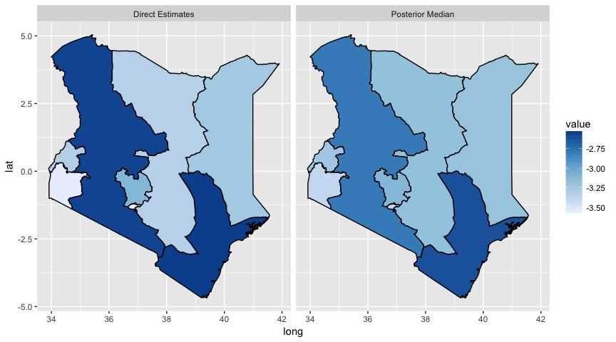

```r
combined <- merge(fit$HT, fit$smooth, by = "region")
mapPlot(data = combined, geo = DemoMap2$geo, variables=c("HT.est", "median"), labels = c("Direct Estimates", "Posterior Median"), by.data = "region", by.geo = "NAME_final", is.long=FALSE)
```